# Chapter 2 Data Wrangling and Data Analysis

*Summary of the week (completed work and learning)*

This Chapter contains two parts: (1) data wrangling and (2) data analysis.

- In data wrangling, we explore a survey data and create an analysis dataset (.csv file) using an R script.
- In data analysis, we explore the dataset further, detail the variables, make graphical plots for analysis, fit OLS regression models and finally conduct diagnostic tests on the final model.
- This report follows the following logic: R script used –> ouputs –> explanations.

## Part 1: data wrangling

We first read the full learning2014 data from “http://www.helsinki.fi/~kvehkala/JYTmooc/JYTOPKYS3-data.txt”. This is a data from survey (3.12.2014 - 10.1.2015) about the-relationship-between-learning-approaches-and-students-achievements-in-an-introductory-statistics-course-in-finland.

It is a 183x60 data consisting of (i) 56 categorical-likert-scale variables (scale 1-5), (ii) 3 numerical variables (age, attitude, points), and (iii) 1 factor variable (gender:female or male).

We create an analysis dataset for the analysis exercise. To produce the dataset, see **create_learning2014.R** file in the folder **data** here: https://github.com/alfanmansur/IODS-project/tree/master/data. And the dataset produced is **newdata2014.csv** file in the same folder.

## Part 2: data analysis

### 2.1 Explore the data

Let’s us firstly run the R script below and print the outputs. We then proceed by reading the outputs.

```r
# Read the data from my local folder
myData <- read.csv('./data/newdata2014.csv')
str(myData)
```

```
## 'data.frame':    166 obs. of  7 variables:
##  $ gender  : chr  "F" "M" "F" "M" ...
##  $ age     : int  53 55 49 53 49 38 50 37 37 42 ...
##  $ attitude: int  37 31 25 35 37 38 35 29 38 21 ...
##  $ deep    : num  3.58 2.92 3.5 3.5 3.67 ...
##  $ stra    : num  3.38 2.75 3.62 3.12 3.62 ...
##  $ surf    : num  2.58 3.17 2.25 2.25 2.83 ...
##  $ points  : int  25 12 24 10 22 21 21 31 24 26 ...
```

```r
head(myData)
```

```
##   gender age attitude     deep  stra     surf points
## 1      F  53       37 3.583333 3.375 2.583333     25
## 2      M  55       31 2.916667 2.750 3.166667     12
## 3      F  49       25 3.500000 3.625 2.250000     24
## 4      M  53       35 3.500000 3.125 2.250000     10
## 5      M  49       37 3.666667 3.625 2.833333     22
## 6      F  38       38 4.750000 3.625 2.416667     21
```

```r
summary(myData)  #Somehow, the variable 'attitude' doesn't have the same scale as the dataset in "http://s3.amazonaws.com/assets.datacamp.com/production/course_2218/datasets/learning2014.txt".
```

```
##     gender               age           attitude          deep
##  Length:166         Min.   :17.00   Min.   :14.00   Min.   :1.583
##  Class :character   1st Qu.:21.00   1st Qu.:26.00   1st Qu.:3.333
##  Mode  :character   Median :22.00   Median :32.00   Median :3.667
##                     Mean   :25.51   Mean   :31.43   Mean   :3.680
##                     3rd Qu.:27.00   3rd Qu.:37.00   3rd Qu.:4.083
##                     Max.   :55.00   Max.   :50.00   Max.   :4.917
##       stra            surf           points
##  Min.   :1.250   Min.   :1.583   Min.   : 7.00
##  1st Qu.:2.625   1st Qu.:2.417   1st Qu.:19.00
##  Median :3.188   Median :2.833   Median :23.00
##  Mean   :3.121   Mean   :2.787   Mean   :22.72
##  3rd Qu.:3.625   3rd Qu.:3.167   3rd Qu.:27.75
##  Max.   :5.000   Max.   :4.333   Max.   :33.00
```

```r
# Here I divide each element of 'attitude' by 10 to match the scale as in the link above.
myData[3] <- lapply(myData[3], `/`, 10)
# Explore the structure and the dimensions of the data
str(myData) #the structure of the data
```

```
## 'data.frame':    166 obs. of  7 variables:
##  $ gender  : chr  "F" "M" "F" "M" ...
##  $ age     : int  53 55 49 53 49 38 50 37 37 42 ...
##  $ attitude: num  3.7 3.1 2.5 3.5 3.7 3.8 3.5 2.9 3.8 2.1 ...
##  $ deep    : num  3.58 2.92 3.5 3.5 3.67 ...
##  $ stra    : num  3.38 2.75 3.62 3.12 3.62 ...
##  $ surf    : num  2.58 3.17 2.25 2.25 2.83 ...
##  $ points  : int  25 12 24 10 22 21 21 31 24 26 ...
```

```r
head(myData)  #display the first 6 observations
```

```
##   gender age attitude     deep  stra     surf points
## 1      F  53      3.7 3.583333 3.375 2.583333     25
## 2      M  55      3.1 2.916667 2.750 3.166667     12
## 3      F  49      2.5 3.500000 3.625 2.250000     24
## 4      M  53      3.5 3.500000 3.125 2.250000     10
## 5      M  49      3.7 3.666667 3.625 2.833333     22
## 6      F  38      3.8 4.750000 3.625 2.416667     21
```

```r
summary(myData)
```

```
##     gender               age           attitude          deep
##  Length:166         Min.   :17.00   Min.   :1.400   Min.   :1.583
##  Class :character   1st Qu.:21.00   1st Qu.:2.600   1st Qu.:3.333
##  Mode  :character   Median :22.00   Median :3.200   Median :3.667
##                     Mean   :25.51   Mean   :3.143   Mean   :3.680
##                     3rd Qu.:27.00   3rd Qu.:3.700   3rd Qu.:4.083
##                     Max.   :55.00   Max.   :5.000   Max.   :4.917
##       stra            surf           points
##  Min.   :1.250   Min.   :1.583   Min.   : 7.00
##  1st Qu.:2.625   1st Qu.:2.417   1st Qu.:19.00
##  Median :3.188   Median :2.833   Median :23.00
##  Mean   :3.121   Mean   :2.787   Mean   :22.72
##  3rd Qu.:3.625   3rd Qu.:3.167   3rd Qu.:27.75
##  Max.   :5.000   Max.   :4.333   Max.   :33.00
```

```r
date()
```

```
## [1] "Thu Nov 11 15:09:11 2021"
```

**About the dataset**

This is a data from survey (3.12.2014 - 10.1.2015) about the-relationship-between-learning-approaches-and-students-achievements-in-an-introductory-statistics-course-in-Finland.

We study the dataset for analysis further in the following section.

### 2.2 A graphical overview of the data and summaries of the variables

We will look at the 7 variables one by one. The first variable is **gender** which takes only two values, female “F” and male “M”. We have observations of 110 females and 56 males out of 166 observations. Or in proportion, we have 66.27 % of females and 33.73 % of males. See the R script and produced outputs below.

```r
gendercounts <- table(myData$gender)
addmargins(gendercounts)
```

```
##
##   F   M Sum
## 110  56 166
```

```r
round(100*prop.table(gendercounts),digits=2)
```

```
##
##     F     M
## 66.27 33.73
```

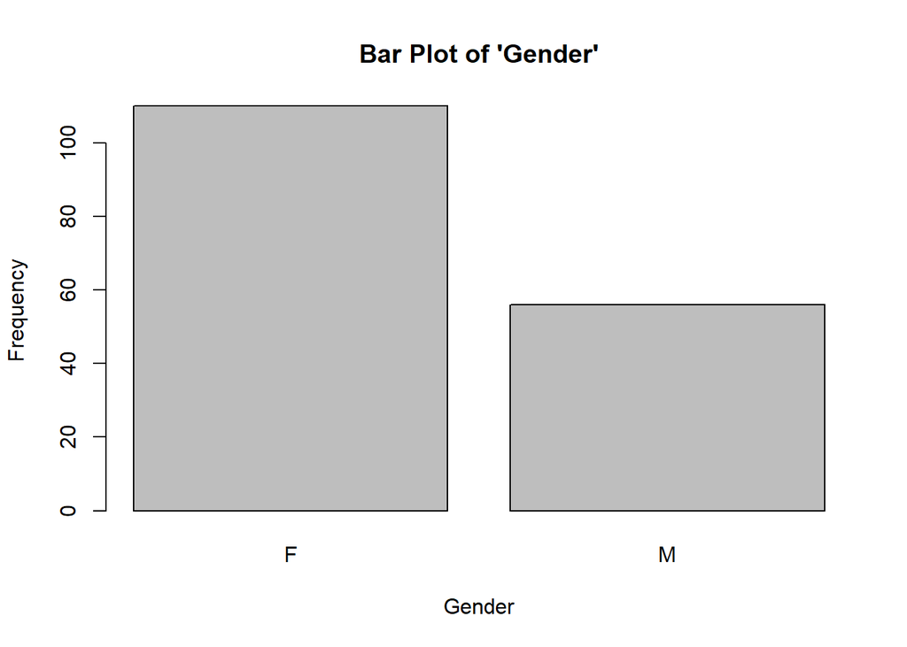

```r
barplot(gendercounts, main="Bar Plot of 'Gender'",
   xlab="Gender", ylab="Frequency")
```

```r
summary(myData$age)
```

```
##    Min. 1st Qu.  Median    Mean 3rd Qu.    Max.
##   17.00   21.00   22.00   25.51   27.00   55.00
```

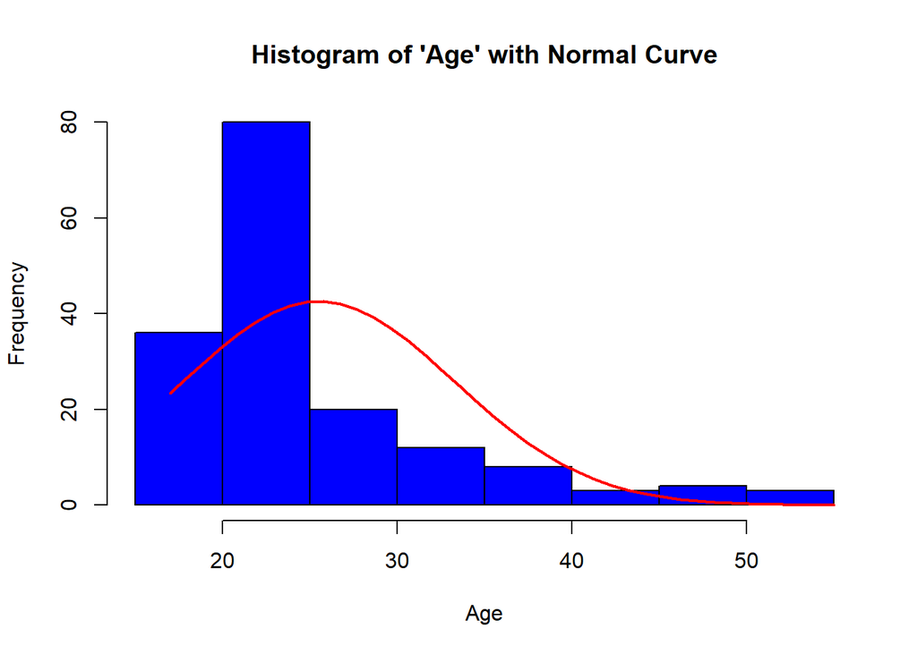

```r
x <- myData$age
h<-hist(x, breaks=10, col="blue", xlab="Age",
   main="Histogram of 'Age' with Normal Curve")
xfit<-seq(min(x),max(x),length=40)
yfit<-dnorm(xfit,mean=mean(x),sd=sd(x))
yfit <- yfit*diff(h$mids[1:2])*length(x)
lines(xfit, yfit, col="red", lwd=2)
```

The third variable is **attitude** which reflects global attitude toward statistics. From the distribution plot, we can safely say that this variable follows a Normal distribution with mean of 3.143 from the summary.

```r
summary(myData$attitude)
```

```
##    Min. 1st Qu.  Median    Mean 3rd Qu.    Max.
##   1.400   2.600   3.200   3.143   3.700   5.000
```

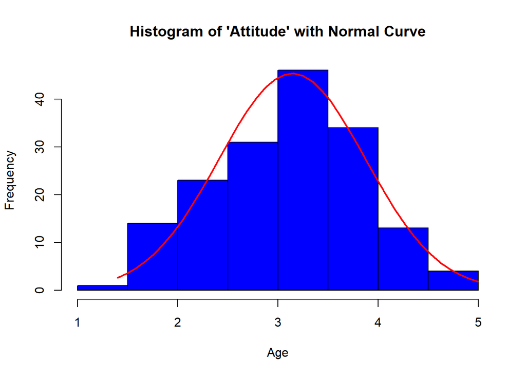

```r
x <- myData$attitude
h<-hist(x, breaks=10, col="blue", xlab="Age",
   main="Histogram of 'Attitude' with Normal Curve")
xfit<-seq(min(x),max(x),length=40)
yfit<-dnorm(xfit,mean=mean(x),sd=sd(x))
yfit <- yfit*diff(h$mids[1:2])*length(x)
lines(xfit, yfit, col="red", lwd=2)
```

The fourth variable is **deep** which reflects factor score of deep approach. From the distribution plot, we can safely say that this variable follows a Normal distribution with mean of 3.680 from the summary.

```r
summary(myData$deep)
```

```
##    Min. 1st Qu.  Median    Mean 3rd Qu.    Max.
##   1.583   3.333   3.667   3.680   4.083   4.917
```

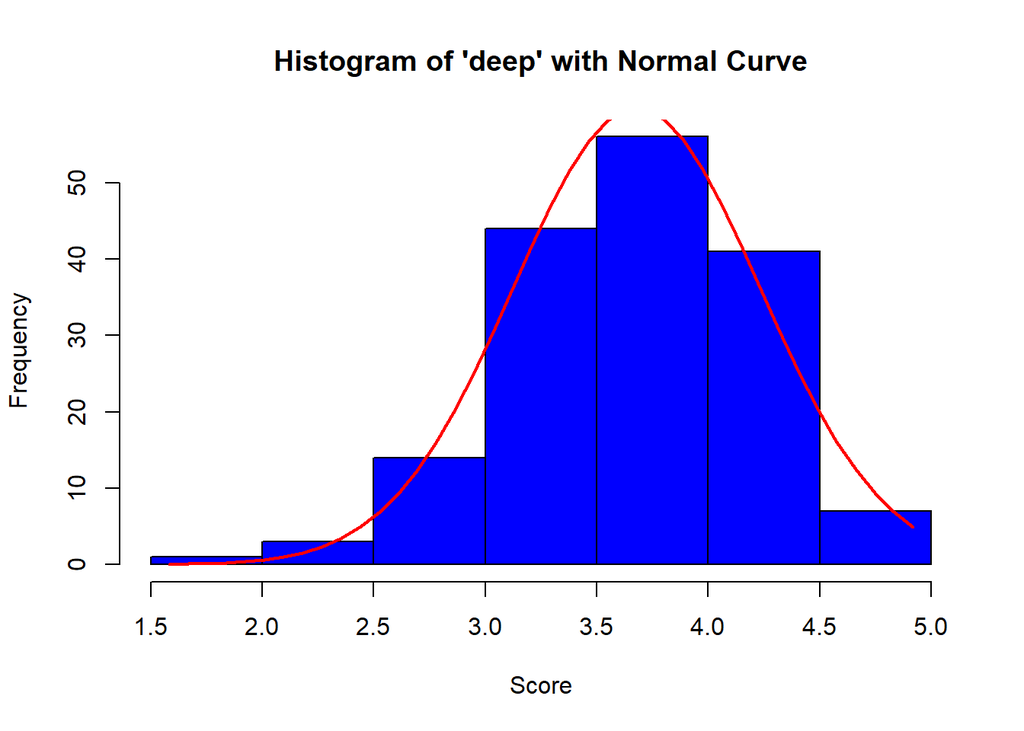

```r
x <- myData$deep
h<-hist(x, breaks=10, col="blue", xlab="Score",
   main="Histogram of 'deep' with Normal Curve")
xfit<-seq(min(x),max(x),length=40)
yfit<-dnorm(xfit,mean=mean(x),sd=sd(x))
yfit <- yfit*diff(h$mids[1:2])*length(x)
lines(xfit, yfit, col="red", lwd=2)
```

The fifth variable is **stra** which stands for factor score of Strategic approach. From the distribution plot, we can safely say that this variable follows a Normal distribution with mean of 3.121 from the summary.

```r
summary(myData$stra)
```

```
##    Min. 1st Qu.  Median    Mean 3rd Qu.    Max.
##   1.250   2.625   3.188   3.121   3.625   5.000
```

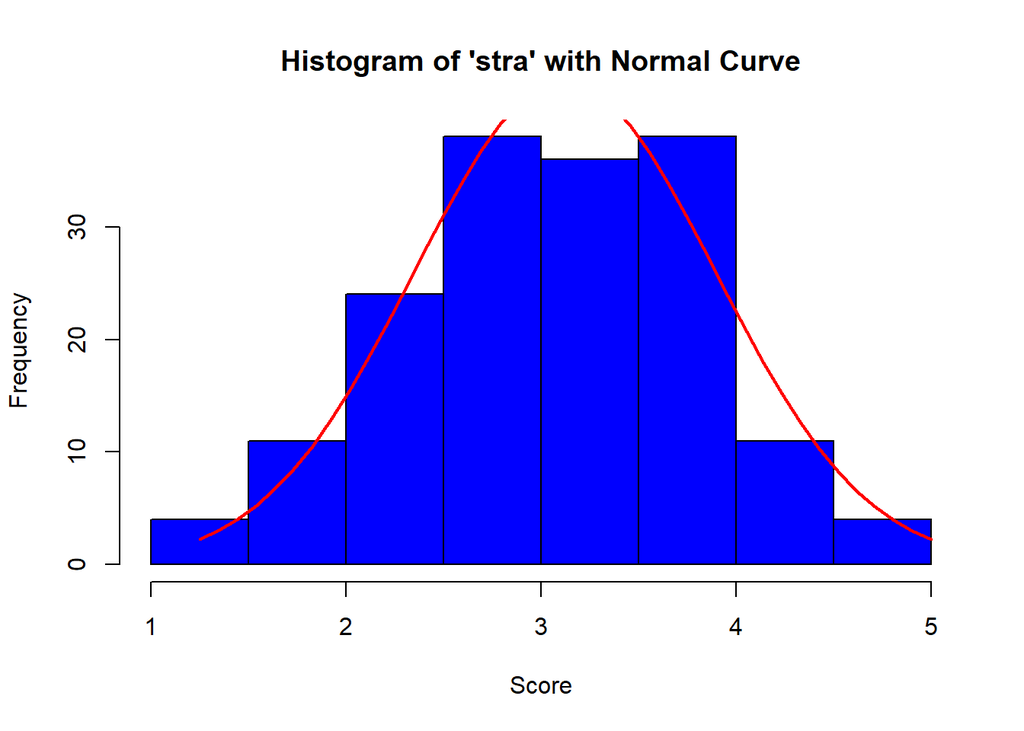

```r
x <- myData$stra
h<-hist(x, breaks=10, col="blue", xlab="Score",
   main="Histogram of 'stra' with Normal Curve")
xfit<-seq(min(x),max(x),length=40)
yfit<-dnorm(xfit,mean=mean(x),sd=sd(x))
yfit <- yfit*diff(h$mids[1:2])*length(x)
lines(xfit, yfit, col="red", lwd=2)
```

The sixth variable is **surf** which stands for factor score of Surface approach. From the distribution plot, we can safely say that this variable follows a Normal distribution with mean of 2.787 from the summary.

```r
summary(myData$surf)
```

```
##    Min. 1st Qu.  Median    Mean 3rd Qu.    Max.
##   1.583   2.417   2.833   2.787   3.167   4.333
```

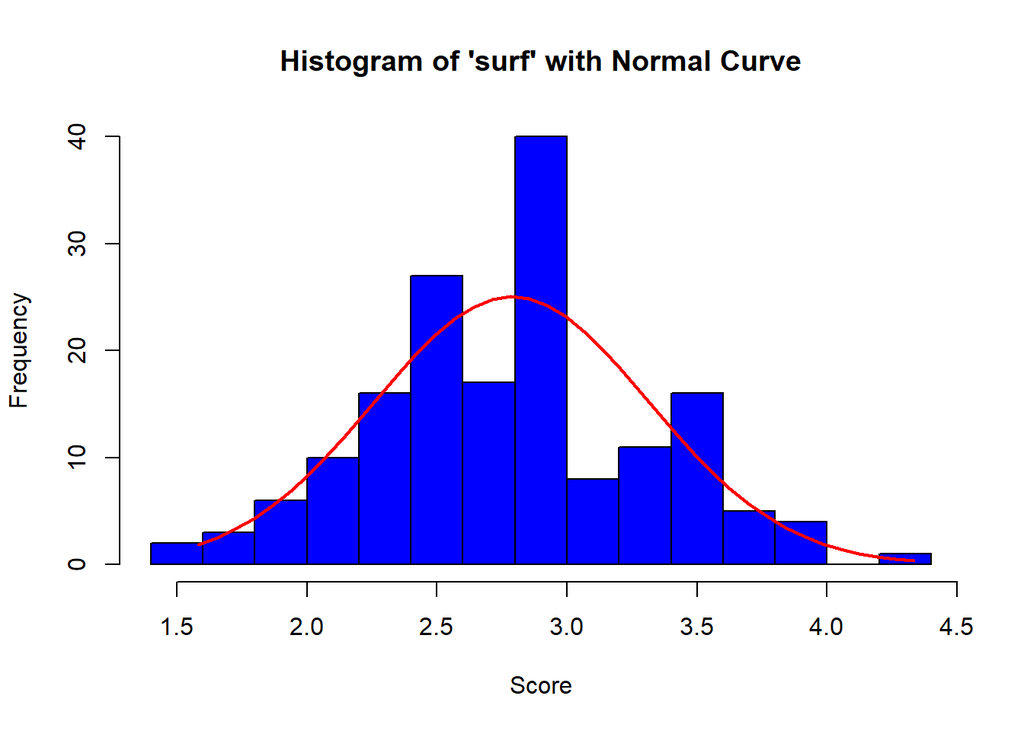

```r
x <- myData$surf
h<-hist(x, breaks=10, col="blue", xlab="Score",
   main="Histogram of 'surf' with Normal Curve")
xfit<-seq(min(x),max(x),length=40)
yfit<-dnorm(xfit,mean=mean(x),sd=sd(x))
yfit <- yfit*diff(h$mids[1:2])*length(x)
lines(xfit, yfit, col="red", lwd=2)
```

Finally, the last variable is **points** which stands for exam points earned. From the distribution plot, it seems that this variable follows a Normal distribution with mean of 22.72 points from the summary.

```r
summary(myData$points)
```

```
##    Min. 1st Qu.  Median    Mean 3rd Qu.    Max.
##    7.00   19.00   23.00   22.72   27.75   33.00
```

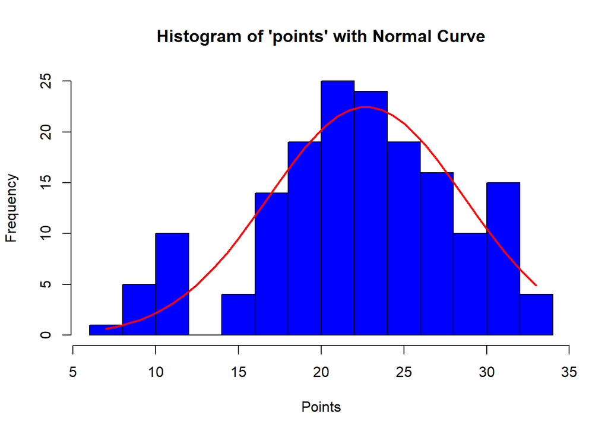

```r
x <- myData$points
h<-hist(x, breaks=10, col="blue", xlab="Points",
   main="Histogram of 'points' with Normal Curve")
xfit<-seq(min(x),max(x),length=40)
yfit<-dnorm(xfit,mean=mean(x),sd=sd(x))
yfit <- yfit*diff(h$mids[1:2])*length(x)
lines(xfit, yfit, col="red", lwd=2)
```

Now, we look at the relationship by analyzing correlation between the 7 variables above. We firstly convert the ‘gender’ variable into numeric 1 for female and 2 for male. From the correlation matrix below, we can see that we have noticeable positive correlation between ‘attitude’ and ‘points’ (0.44) and between ‘attitude’ and ‘gender’ (0.29). We also have noticeable negative correlation between ‘deep’ and ‘surf’.

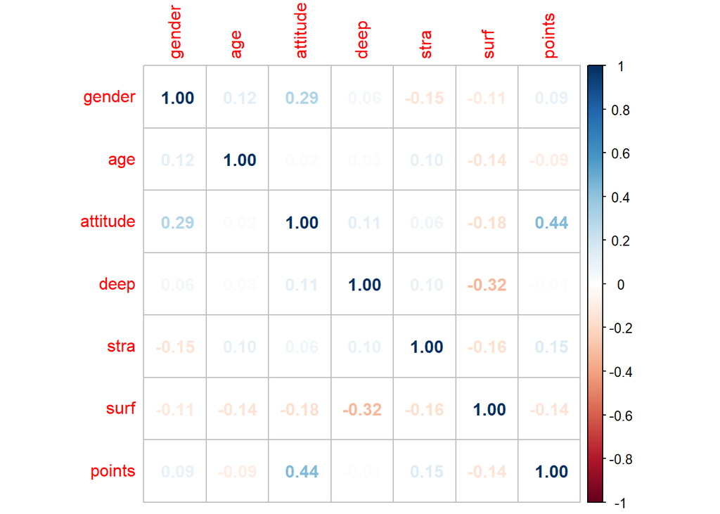

```r
rf <- factor(myData$gender)
myData$gender <- as.numeric(rf) # convert character variable to numeric
library(corrplot)
M = cor(myData)
corrplot(M, method = 'number')  # produce correlation matrix
```

### 2.3 Fit a regression model

Having observed the correlation matrix in the previous section above, I pick up ‘attitude’, ‘gender’, and ‘stra’ as three explanatory variables to fit a regression model where exam points is the target (dependent) variable.

```r
# fit a regression model (model 1)
model <- lm(points ~ attitude + gender + stra, data = myData)
# display the actual coefficients
equatiomatic::extract_eq(model)
```

$$\operatorname{points} = \alpha + \beta_{1}(\operatorname{attitude}) + \beta_{2}(\operatorname{gender}) + \beta_{3}(\operatorname{stra}) + \epsilon$$

```r
summary(model)
```

```
##
## Call:
## lm(formula = points ~ attitude + gender + stra, data = myData)
##
## Residuals:
##      Min       1Q   Median       3Q      Max
## -17.7179  -3.3285   0.5343   3.7412  10.9007
##
## Coefficients:
##             Estimate Std. Error t value Pr(>|t|)
## (Intercept)   9.2034     2.5851   3.560 0.000487 ***
## attitude      3.5100     0.5956   5.893 2.13e-08 ***
## gender       -0.2236     0.9248  -0.242 0.809231
## stra          0.8911     0.5441   1.638 0.103419
## ---
## Signif. codes:  0 '***' 0.001 '**' 0.01 '*' 0.05 '.' 0.1 ' ' 1
##
## Residual standard error: 5.304 on 162 degrees of freedom
## Multiple R-squared:  0.2051, Adjusted R-squared:  0.1904
## F-statistic: 13.93 on 3 and 162 DF,  p-value: 3.982e-08
```

```r
# display the actual coefficients
equatiomatic::extract_eq(model, use_coefs = TRUE)
```

$$\operatorname{\widehat{points}} = 9.2 + 3.51(\operatorname{attitude}) - 0.22(\operatorname{gender}) + 0.89(\operatorname{stra})$$

Summary of the fitted model can be seen from the display above. In terms of the goodness of fit, it performs adequately well although weak, where it features R-squared of 0.2051, meaning that 20.51 of the variance in the exam points can be explained collectively by ‘attitude’, ‘gender’, and ‘stra’. On the other hand, the Adjusted R-squared refers to the R-squared adjusted for the number of predictors in the model. Adding more predictors may increase both the R-squared and the Adjusted R-squared, if the predictors turn out to be significant. Otherwise, it will decrease the Adjusted R-squared. Typically, the Adjusted R-squared is lower from the R-squared as we can see from the summary above (0.1904).

As for significance, among the three explanatory variables, only ‘attitude’ is significant. The significance test is based on the t-statistic of 5.893 which comes from the Estimate of 3.51 divided by the Std. Error of 0.5956. The coefficient of ‘attitude’ of 3.51 can be interpreted as if attitude score increases by 1 unit, the exam points will increase by 3.51 points.

Next, we consider to remove ‘gender’ and ‘stra’ from the model as they are insignificant.

### 2.4. Fit another regression model

```r
# gender and stra are removed and fit the model again without them (model 2)
model2 <- lm(points ~ attitude, data = myData)
# Show the theoretical model (model2)
equatiomatic::extract_eq(model2)
```

$$\operatorname{points} = \alpha + \beta_{1}(\operatorname{attitude}) + \epsilon$$

```r
summary(model2)
```

```
##
## Call:
## lm(formula = points ~ attitude, data = myData)
##
## Residuals:
##      Min       1Q   Median       3Q      Max
## -16.9763  -3.2119   0.4339   4.1534  10.6645
##
## Coefficients:
##             Estimate Std. Error t value Pr(>|t|)
## (Intercept)  11.6372     1.8303   6.358 1.95e-09 ***
## attitude      3.5255     0.5674   6.214 4.12e-09 ***
## ---
## Signif. codes:  0 '***' 0.001 '**' 0.01 '*' 0.05 '.' 0.1 ' ' 1
##
## Residual standard error: 5.32 on 164 degrees of freedom
## Multiple R-squared:  0.1906, Adjusted R-squared:  0.1856
## F-statistic: 38.61 on 1 and 164 DF,  p-value: 4.119e-09
```

```r
# display the actual coefficients
equatiomatic::extract_eq(model2, use_coefs = TRUE)
```

$$\operatorname{\widehat{points}} = 11.64 + 3.53(\operatorname{attitude})$$

With only one explanatory variable i.e. ‘attitude’, this model has a slightly lower goodness of fit with R-squared of 0.1906, compared to the model 1 previously. The Adjusted R-squared of 0.1856 is also lower which makes sense since we only have one predictor in the model. About the Adjusted R-squared, it has already been explained in the previous paragraph above. In terms of parameter coefficients, ‘attitude’ is still significant though with a high power of the test. It is based on the t-statistic value of 6.214 which results from the Estimate divided by the Std. Error. The estimate of 3.5255 means that if ‘attitude’ score increases by 1 point, then the exam points will increase by 3.5255 points.

Since ‘attitude’ is composed from Da+Db+Dc+Dd+De+Df+Dg+Dh+Di+Dj indexes in the survey, then the following things will positively impact the exam points:  
- Da: I feel confident I can master statistics topics  
- Db: Statistics will be useful for my future work  
- Dc: I am interested in understanding statistics  
- Dd: I did well in high school mathematics courses  
- De: I am interested in learning statistics  
- Df: I feel insecure when I have to do statistics problems  
- Dg: I like statistics  
- Dh: I am scared by statistics  
- Di: I feel confident in doing math operations  
- Dj: Statistics will be useful for my future studies  
In shorter words, it’s all about the feelings of confidence and self motivation that may increase the exam points.